How to Data

# How to create basic plots

## Description

Plotting is a huge topic with many options and variations, but the most foundational types of plots are a line plot and a scatterplot. How can we create those?

Related tasks:

- How to add details to a plot
- How to create a histogram
- How to create a box (and whisker) plot
- How to change axes, ticks, and scale in a plot
- How to create bivariate plots to compare groups
- How to plot interaction effects of treatments

## Using Matplotlib, in Python

View this solution alone.

We will create some fake data using Python lists, for simplicity. But everything we show below works also if your data is in columns of a DataFrame, such as `df['age']`.

```python
patient_id     = [   0,   1,   2,   3,   4,   5,   6,   7,   8,   9 ]
patient_height = [  60,  64,  64,  65,  66,  66,  70,  72,  72,  76 ]
patient_weight = [ 141, 182, 169, 204, 138, 198, 180, 175, 244, 196 ]
```

The conventional way to import matplotlib in Python is as follows.

```python
import matplotlib.pyplot as plt
```

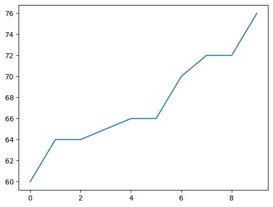

```python
plt.plot( patient_id, patient_height )         # create plot
plt.show()                                     # display plot
```

You can make a scatterplot as follows.

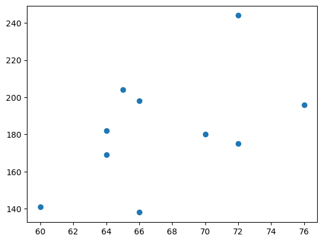

```python
plt.scatter( patient_height, patient_weight )  # create plot
plt.show()                                     # display plot
```

If your data is already in a pandas DataFrame, there are shortcuts:

```python
# Plot all columns:
df.plot()
plt.show()

# Plot all columns in separate subplots:
df.plot( subplots = True )
plt.show()

# Plot one column:
df['column'].plot()
plt.show()

# Plot specific columns:
df.plot( x='col name', y='other col name' )
plt.show()
```

Content last modified on 24 July 2023.

See a problem? [Tell us](https://github.com/nathancarter/how2data/issues/new/choose) or edit the source.

## Solution, in R

View this solution alone.

We will create some fake data using vectors, for simplicity. But everything we show below works also if your data is in columns of a DataFrame.

```r
patient.id     <- c(0, 1, 2, 3, 4, 5, 6, 7, 8, 9)
patient.height <- c(60,  64,  64,  65,  66,  66,  70,  72,  72,  76)
patient.weight <- c(141, 182, 169, 204, 138, 198, 180, 175, 244, 196)
```

We can make a line plot if we use the `type="l"` option (which is an “ell,” not a number one).

```r
plot(patient.id, patient.height, main="Patient heights", type="l")
```

[figure not shown]

We can create a scatterplot if we have two numerical columns, such as the height and weight in the data above.

```r
plot(patient.height, patient.weight, main = "Height vs. Weight")
```

[figure not shown]

Content last modified on 24 July 2023.

See a problem? [Tell us](https://github.com/nathancarter/how2data/issues/new/choose) or edit the source.

## Topics that include this task

- Bentley University MA346

## Opportunities

This website does not yet contain a solution for this task in any of the following software packages.

- Excel
- Julia

If you can contribute a solution using any of these pieces of software, see our Contributing page for how to help extend this website.